### Analyzing Graduate School Data (Assginment 9)

For this assignment I am exploring and modeling the predictors of graduate school admission. First, load required packages:

```r
library(tidyverse)
library(modelr)
library(easystats)
library(GGally)
library(caret)
```

Let’s load and look at this data.

```r
grad_dat <- read.csv('../../Data/GradSchool_Admissions.csv')
glimpse(grad_dat)
```

```
## Rows: 400
## Columns: 4
## $ admit <int> 0, 1, 1, 1, 0, 1, 1, 0, 1, 0, 0, 0, 1, 0, 1, 0, 0, 0, 0, 1, 0, 1…
## $ gre   <int> 380, 660, 800, 640, 520, 760, 560, 400, 540, 700, 800, 440, 760,…
## $ gpa   <dbl> 3.61, 3.67, 4.00, 3.19, 2.93, 3.00, 2.98, 3.08, 3.39, 3.92, 4.00…
## $ rank  <int> 3, 3, 1, 4, 4, 2, 1, 2, 3, 2, 4, 1, 1, 2, 1, 3, 4, 3, 2, 1, 3, 2…
```

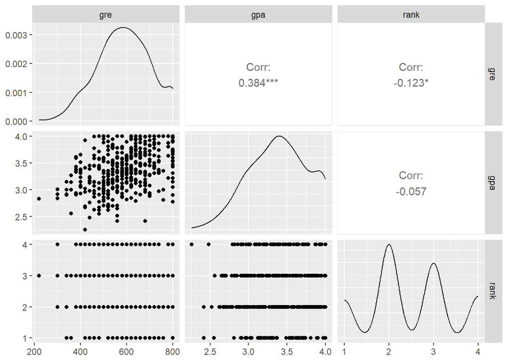

```r
grad_dat %>%
  select(gre, gpa, rank) %>%
  ggpairs()
```

I am going to model on admit, and define 4 different potential models.

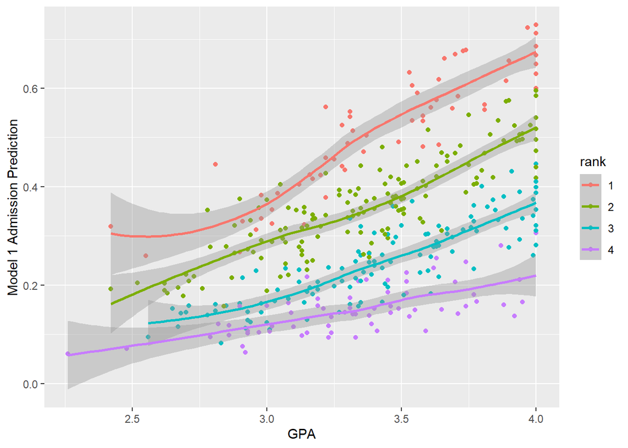

```r
mod1 = glm(formula = as.logical(admit) ~(gpa+gre)*rank,
           data = grad_dat,
           family = 'binomial')

grad_dat$pred1 <- predict(mod1, grad_dat, type = 'response')

grad_dat %>%
  ggplot(aes(x = gpa,
             y = pred1,
             color = factor(rank))) +
  geom_point() +
  geom_smooth() +
  labs(x = "GPA", y = "Model 1 Admission Prediction") +
  guides(color = guide_legend(title = "rank"))
```

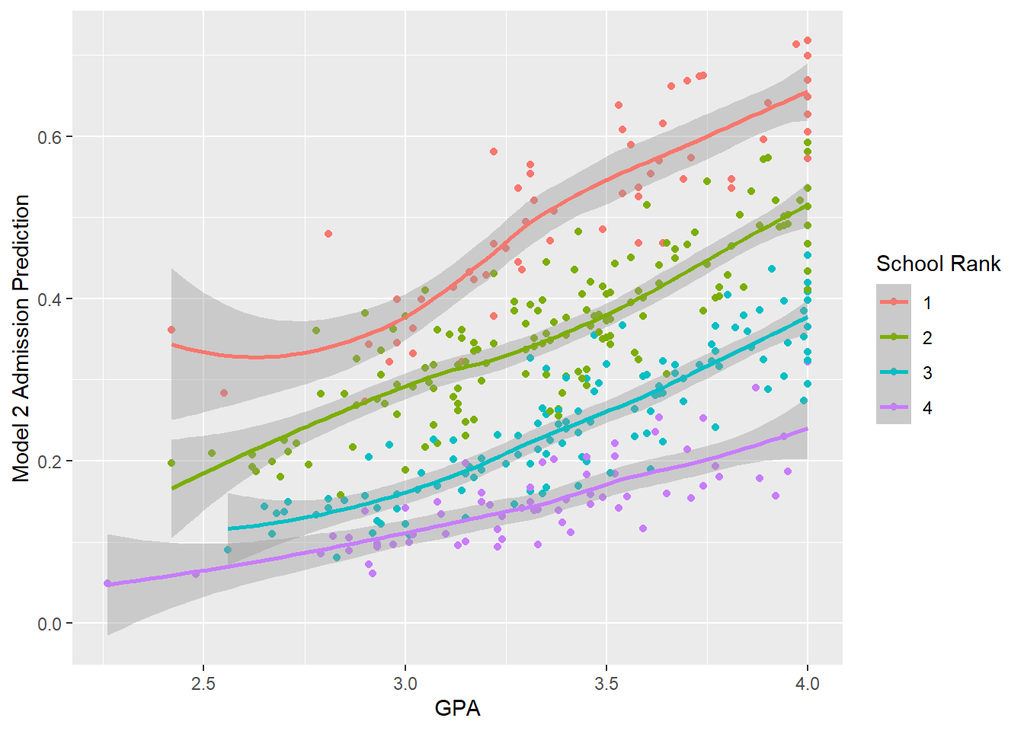

```r
mod2 <- glm(formula = as.logical(admit)~(gpa+gre+rank),
            data = grad_dat,
            family = 'binomial')

grad_dat$pred2 <- predict(mod2, grad_dat, type = 'response')

grad_dat %>%
  ggplot(aes(x = gpa,
             y = pred2,
             color = factor(rank))) +
  geom_point() +
  geom_smooth() +
  labs(x = "GPA", y = "Model 2 Admission Prediction") +
  guides(color = guide_legend(title = "School Rank"))
```

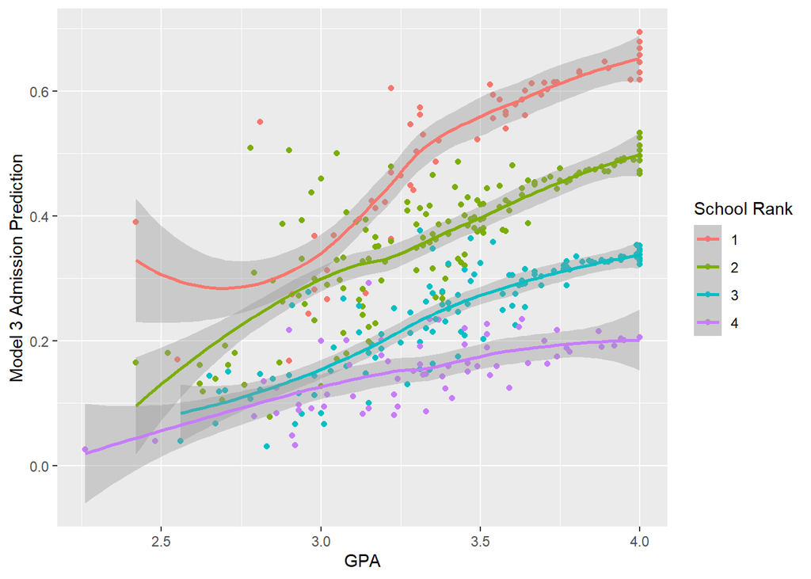

```r
mod3 <- glm(formula = as.logical(admit)~gpa*gre*rank,
            data = grad_dat,
            family = 'binomial')

grad_dat$pred3 <- predict(mod3, grad_dat, type = 'response')

grad_dat %>%
  ggplot(aes(x = gpa,
             y = pred3,
             color = factor(rank))) +
  geom_point() +
  geom_smooth() +
  labs(x = "GPA", y = "Model 3 Admission Prediction") +
  guides(color = guide_legend(title = "School Rank"))
```

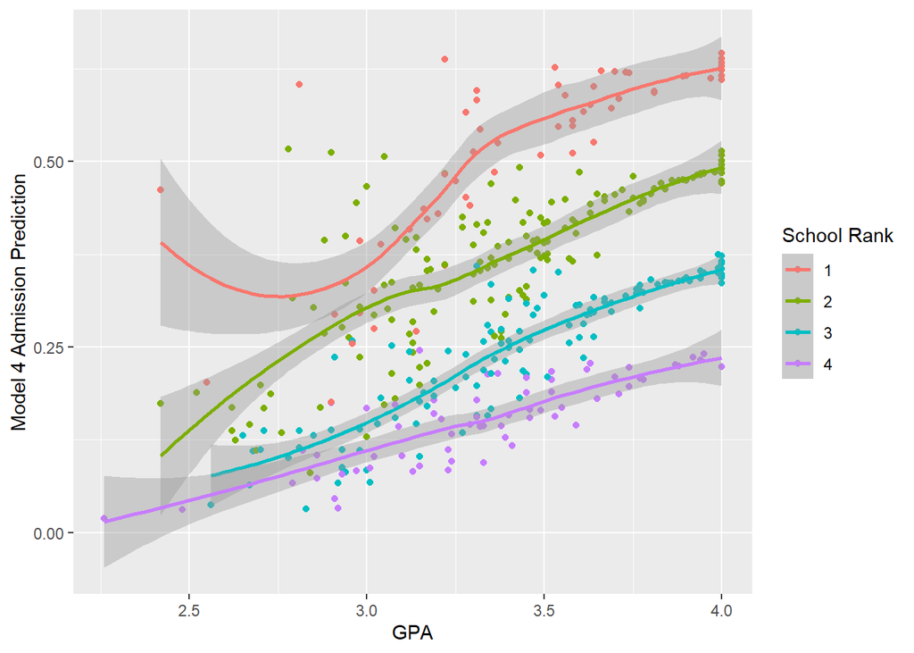

```r
mod4 <- glm(formula = as.logical(admit)~gpa*gre+rank,
            data = grad_dat,
            family = 'binomial')

grad_dat$pred4 <- predict(mod4, grad_dat, type = 'response')

grad_dat %>%
  ggplot(aes(x = gpa,
             y = pred4,
             color = factor(rank))) +
  geom_point() +
  geom_smooth() +
  labs(x = "GPA", y = "Model 4 Admission Prediction") +
  guides(color = guide_legend(title = "School Rank"))
```

Let’s compare the performance of each of these models.

```r
compare_performance(mod1, mod2, mod3, mod4)
```

```
## # Comparison of Model Performance Indices
##
## Name | Model | AIC (weights) | AICc (weights) | BIC (weights) | Tjur's R2
## -------------------------------------------------------------------------
## mod1 |   glm | 471.3 (0.052) |  471.5 (0.050) | 495.3 (0.002) |     0.100
## mod2 |   glm | 467.4 (0.362) |  467.5 (0.370) | 483.4 (0.826) |     0.099
## mod3 |   glm | 472.2 (0.033) |  472.6 (0.029) | 504.2 (<.001) |     0.106
## mod4 |   glm | 466.6 (0.553) |  466.7 (0.550) | 486.6 (0.171) |     0.105
##
## Name |  RMSE | Sigma | Log_loss | Score_log | Score_spherical |   PCP
## ---------------------------------------------------------------------
## mod1 | 0.442 |     1 |    0.574 |   -50.582 |           0.005 | 0.610
## mod2 | 0.442 |     1 |    0.574 |   -50.496 |           0.004 | 0.609
## mod3 | 0.440 |     1 |    0.570 |   -50.593 |           0.005 | 0.613
## mod4 | 0.440 |     1 |    0.571 |   -50.481 |           0.004 | 0.612
```

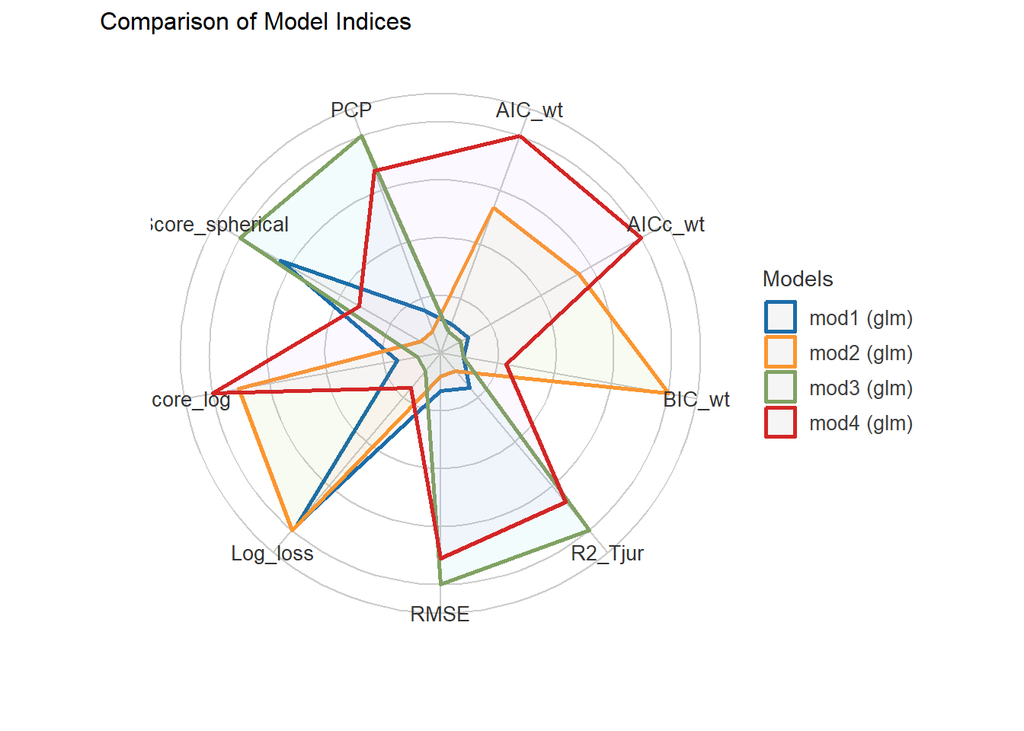

```r
compare_performance(mod1, mod2, mod3, mod4) %>% plot()
```

Model 4 has the lowest AIC scores, but all of the models are relatively similar with their RMSE and R2 scores. Looking at the plots, the models are performing very similarly. I’m going to do some cross validation to compare how model 2 and model 4 perform.

I’m splitting the data into training and testing sets.

```r
id <- createDataPartition(grad_dat$admit, p = 0.8, list = FALSE)

train <- grad_dat[id,]
test <- grad_dat[-id,]
```

I’m now going to retrain the models.

```r
mod2_formula <- mod2$formula
mod2 <- glm(data = train, formula = mod2_formula)

mod4_formula <- mod4$formula
mod4 <- glm(data = train, formula = mod4_formula)
```

Now, I’m going to evaluate Models 2 and 4.

```r
compare_performance(mod2, mod4, rank = TRUE)
```

```
## # Comparison of Model Performance Indices
##
## Name | Model |    R2 |  RMSE | Sigma | AIC weights | AICc weights | BIC weights | Performance-Score
## ---------------------------------------------------------------------------------------------------
## mod2 |   glm | 0.113 | 0.447 | 0.450 |       0.683 |        0.691 |       0.934 |            66.67%
## mod4 |   glm | 0.114 | 0.447 | 0.451 |       0.317 |        0.309 |       0.066 |            33.33%
```

### Takeaways

-Both models have low R2 (variance) values, but Model 4 explains slightly more variance.

-Model 2 has higher BIC weights, which suggests that Model 2 is simpler and preferred under BIC.